# lab4-vignette

Dharani Ganesan and Marc Braun

```r
library(lab4)
```

## Setup

To install the lab4 package, source it from GitHub with the command `devtools::install_github("Marbr987/lab4")`.

## Usage of linreg function

The `linreg()` function can be used to perform a linear regression. It takes two arguments, `formula` and `data`, where `formula` is the formula consisting of parameters of `data` used to perform the regression. The function returns an object of class linreg.  
The following example illustrates the use of `linreg()` with the `iris` dataset, which is also included in this package.

```r
# Crate an object of class linreg by calling the linreg function
linreg_obj <- linreg(formula = Petal.Length ~ Species, data = iris)
class(linreg_obj)
```

```
#> [1] "linreg"
```

```r
# The linreg object is a list containing the following elements
names(linreg_obj)
```

```
#> [1] "call"                               "regression_coefficient"
#> [3] "fitted_values"                      "residuals"
#> [5] "degree_of_freedom"                  "residual_variance"
#> [7] "variance_of_regression_coefficient" "t_values"
#> [9] "p_values"
```

## Usage of methods for linreg objects

The `print()` method prints out the call of the function and the coefficients of the linear regresion.

```r
print(linreg_obj)
```

```
#> Call:
#> linreg(formula = Petal.Length ~ Species, data = iris)
#>
#> Coefficients:
#>       (Intercept) Speciesversicolor  Speciesvirginica
#>             1.462             2.798             4.090
```

The `plot()` function provides the two plots shown in the example below. It returns the plots in a list of size two.

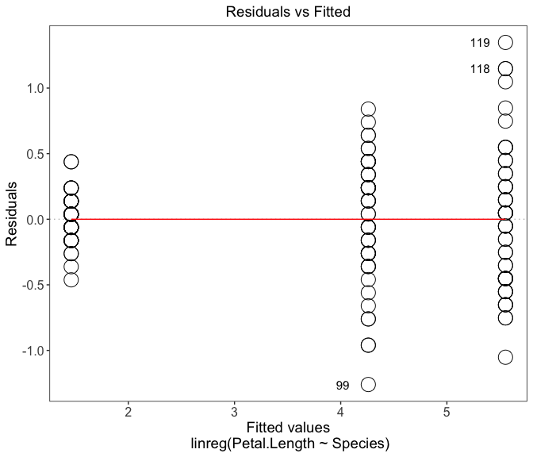

[output not shown]

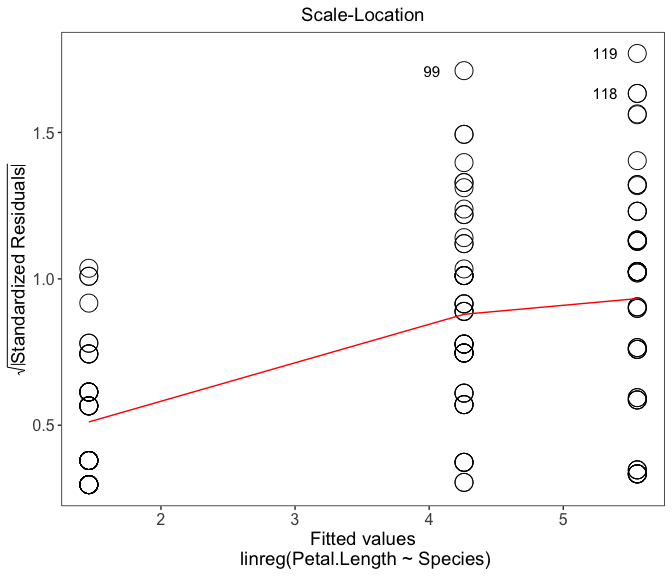

```
#> [1] 0.511254
#> [1] 0.8790328
#> [1] 0.9325399
```

```r
plot_list <- plot(linreg_obj)
print(plot_list[1])
```

The `resid()` method prints out the residuals of the linear regression.

```r
head(resid(linreg_obj))
```

```
#> [1] -0.062 -0.062 -0.162  0.038 -0.062  0.238
```

The `pred()` method prints out the target values predicted by the linear regression.

```r
head(pred(linreg_obj))
```

```
#> [1] 1.462 1.462 1.462 1.462 1.462 1.462
```

The `coef()` method prints out the coefficients of the linear regression.

```r
coef(linreg_obj)
```

```
#>       (Intercept) Speciesversicolor  Speciesvirginica
#>             1.462             2.798             4.090
```

The `summary()` method prints a summary of the linear regression as seen in the example below.

```r
summary(linreg_obj)
```

```
#> Coefficients:
#>                   Estimate Std..Error  t.value p.value  V5
#> (Intercept)          1.462 0.06085848 24.02294  <2e-16 ***
#> Speciesversicolor    2.798 0.08606689 32.50960  <2e-16 ***
#> Speciesvirginica     4.090 0.08606689 47.52118  <2e-16 ***
#> ---
#> Signif. codes:  0 '***' 0.001 '**' 0.01 '*' 0.05 '.' 0.1 ' ' 1
#>
#> Residual standard error: 0.4303345 on 147 degrees of freedom
```